[Edit on GitHub](https://github.com/arviz-devs/ArviZ.jl/blob/master/docs/src/quickstart.md)

# ArviZ.jl Quickstart

Note

This tutorial is adapted from [ArviZ's quickstart](https://arviz-devs.github.io/arviz/notebooks/Introduction.html).

```julia
using ArviZ
using PyPlot

# ArviZ ships with style sheets!
ArviZ.use_style("arviz-darkgrid")
```

## Get started with plotting

ArviZ.jl is designed to be used with libraries like [CmdStan](https://github.com/StanJulia/CmdStan.jl), [Turing.jl](https://turing.ml), and Soss.jl but works fine with raw arrays.

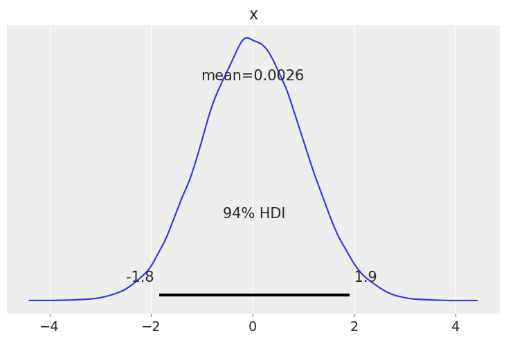

```julia
using Random

rng = Random.MersenneTwister(37772)
plot_posterior(randn(rng, 100_000));
gcf()
```

Plotting a dictionary of arrays, ArviZ.jl will interpret each key as the name of a different random variable. Each row of an array is treated as an independent series of draws from the variable, called a *chain*. Below, we have 10 chains of 50 draws each for four different distributions.

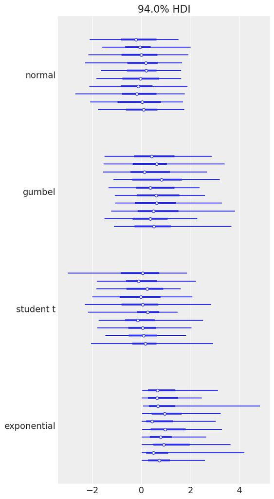

```julia
using Distributions

s = (10, 50)
plot_forest(Dict(
    "normal" => randn(rng, s),
    "gumbel" => rand(rng, Gumbel(), s),
    "student t" => rand(rng, TDist(6), s),
    "exponential" => rand(rng, Exponential(), s)
));
gcf()
```

## Plotting with MCMCChains.jl's `Chains` objects produced by Turing.jl

ArviZ is designed to work well with high dimensional, labelled data. Consider the [eight schools model](https://statmodeling.stat.columbia.edu/2014/01/21/everything-need-know-bayesian-statistics-learned-eight-schools/), which roughly tries to measure the effectiveness of SAT classes at eight different schools. To show off ArviZ's labelling, I give the schools the names of [a different eight schools](https://en.wikipedia.org/wiki/Eight_Schools_Association).

This model is small enough to write down, is hierarchical, and uses labelling. Additionally, a centered parameterization causes [divergences](https://mc-stan.org/users/documentation/case-studies/divergences_and_bias.html) (which are interesting for illustration).

First we create our data and set some sampling parameters.

```julia
J = 8
y = [28.0, 8.0, -3.0, 7.0, -1.0, 1.0, 18.0, 12.0]
σ = [15.0, 10.0, 16.0, 11.0, 9.0, 11.0, 10.0, 18.0]
schools = [
    "Choate",
    "Deerfield",
    "Phillips Andover",
    "Phillips Exeter",
    "Hotchkiss",
    "Lawrenceville",
    "St. Paul's",
    "Mt. Hermon"
];

nwarmup, nsamples, nchains = 1000, 1000, 4;
```

Now we write and run the model using Turing:

```julia
using Turing

Turing.@model turing_model(
    J,
    y,
    σ,
    ::Type{TV} = Vector{Float64},
) where {TV} = begin
    μ ~ Normal(0, 5)
    τ ~ truncated(Cauchy(0, 5), 0, Inf)
    θ = TV(undef, J)
    θ .~ Normal(μ, τ)
    for i in eachindex(y)
        y[i] ~ Normal(θ[i], σ[i])
    end
    return y
end

param_mod = turing_model(J, y, σ)
sampler = NUTS(nwarmup, 0.8)

rng = Random.MersenneTwister(16653)
turing_chns = sample(
    rng,
    param_mod,
    sampler,
    MCMCThreads(),
    nwarmup + nsamples,
    nchains;
    progress = false,
);
```

```
┌ Info: Found initial step size
└   ϵ = 1.6
```

Most ArviZ functions work fine with `Chains` objects from Turing:

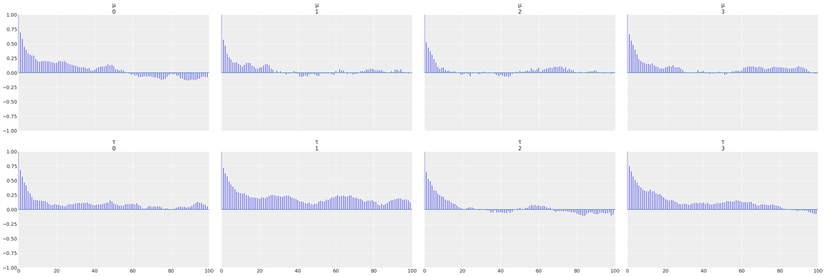

```julia
plot_autocorr(turing_chns; var_names = ["μ", "τ"]);
gcf()
```

### Convert to `InferenceData`

For much more powerful querying, analysis and plotting, we can use built-in ArviZ utilities to convert `Chains` objects to xarray datasets. Note we are also giving some information about labelling.

ArviZ is built to work with `InferenceData` (a netcdf datastore that loads data into `xarray` datasets), and the more *groups* it has access to, the more powerful analyses it can perform.

```julia
idata = from_mcmcchains(
    turing_chns,
    coords = Dict("school" => schools),
    dims = Dict(
        "y" => ["school"],
        "σ" => ["school"],
        "θ" => ["school"],
    ),
    library = "Turing",
)
```

InferenceData

- posterior

  ```
  Dataset (xarray.Dataset)
  Dimensions:  (chain: 4, draw: 1000, school: 8)
  Coordinates:
    * chain    (chain) int64 0 1 2 3
    * draw     (draw) int64 0 1 2 3 4 5 6 7 8 ... 992 993 994 995 996 997 998 999
    * school   (school) <U16 'Choate' 'Deerfield' ... "St. Paul's" 'Mt. Hermon'
  Data variables:
      μ        (chain, draw) float64 2.242 7.977 5.731 5.574 ... 4.085 2.973 7.224
      τ        (chain, draw) float64 5.526 6.236 4.726 6.596 ... 2.249 1.253 2.106
      θ        (chain, draw, school) float64 4.309 9.479 10.76 ... 8.703 8.909
  Attributes:
      created_at:         2020-10-21T04:32:37.291014
      arviz_version:      0.10.0
      inference_library:  Turing
  ```

- sample_stats

  ```
  Dataset (xarray.Dataset)
  Dimensions:           (chain: 4, draw: 1000)
  Coordinates:
    * chain             (chain) int64 0 1 2 3
    * draw              (draw) int64 0 1 2 3 4 5 6 ... 993 994 995 996 997 998 999
  Data variables:
      energy            (chain, draw) float64 64.14 65.4 63.17 ... 54.05 54.95
      energy_error      (chain, draw) float64 -0.02879 0.04508 ... -0.05148
      depth             (chain, draw) int64 4 4 4 4 4 4 4 4 4 ... 3 4 4 3 4 4 3 5
      diverging         (chain, draw) bool False False False ... False False False
      log_density       (chain, draw) float64 -59.74 -59.23 ... -48.34 -49.35
      max_energy_error  (chain, draw) float64 -0.03812 0.08593 ... -0.7244 -0.6883
      nom_step_size     (chain, draw) float64 0.2857 0.2857 ... 0.09645 0.09645
      is_accept         (chain, draw) float64 1.0 1.0 1.0 1.0 ... 1.0 1.0 1.0 1.0
      tree_size         (chain, draw) int64 15 15 15 15 15 15 ... 15 15 15 15 47
      lp                (chain, draw) float64 -59.74 -59.23 ... -48.34 -49.35
      step_size         (chain, draw) float64 0.2857 0.2857 ... 0.09645 0.09645
      mean_tree_accept  (chain, draw) float64 0.9954 0.9501 ... 0.959 0.9753
  Attributes:
      created_at:         2020-10-21T04:32:37.324447
      arviz_version:      0.10.0
      inference_library:  Turing
  ```

Each group is an `ArviZ.Dataset` (a thinly wrapped `xarray.Dataset`). We can view a summary of the dataset.

```julia
idata.posterior
```

```
Dataset (xarray.Dataset)
Dimensions:  (chain: 4, draw: 1000, school: 8)
Coordinates:
  * chain    (chain) int64 0 1 2 3
  * draw     (draw) int64 0 1 2 3 4 5 6 7 8 ... 992 993 994 995 996 997 998 999
  * school   (school) <U16 'Choate' 'Deerfield' ... "St. Paul's" 'Mt. Hermon'
Data variables:
    μ        (chain, draw) float64 2.242 7.977 5.731 5.574 ... 4.085 2.973 7.224
    τ        (chain, draw) float64 5.526 6.236 4.726 6.596 ... 2.249 1.253 2.106
    θ        (chain, draw, school) float64 4.309 9.479 10.76 ... 8.703 8.909
Attributes:
    created_at:         2020-10-21T04:32:37.291014
    arviz_version:      0.10.0
    inference_library:  Turing
```

Here is a plot of the trace. Note the intelligent labels.

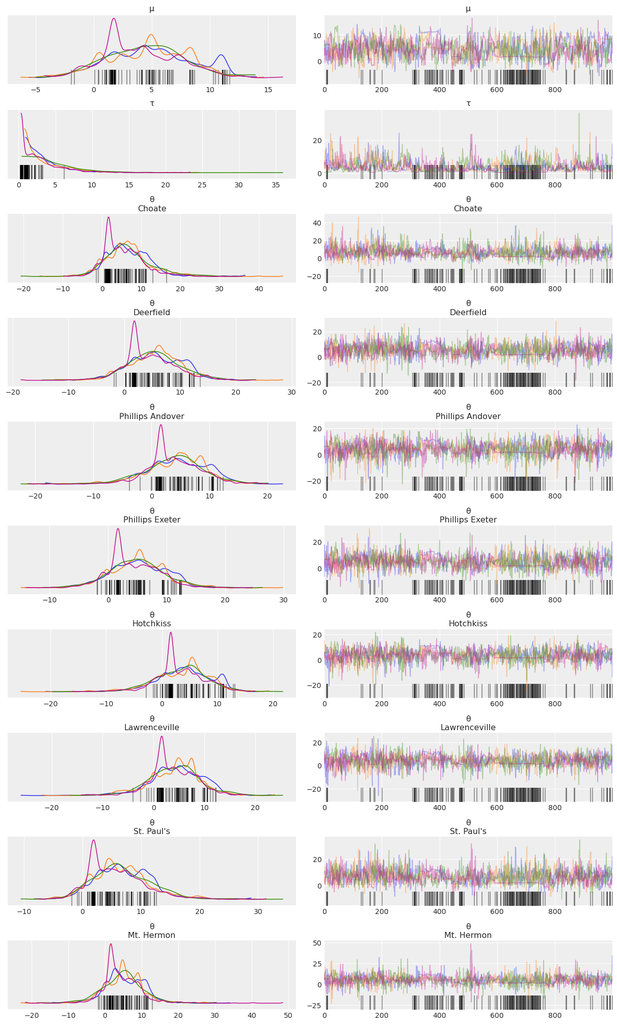

```julia
plot_trace(idata);
gcf()
```

We can also generate summary stats

```julia
summarystats(idata)
```

|  | variable String | mean Float64 | sd Float64 | hdi_3% Float64 | hdi_97% Float64 | mcse_mean Float64 | mcse_sd Float64 | ess_mean Float64 | ess_sd Float64 | ess_bulk Float64 | ess_tail Float64 | r_hat Float64 |
| --- | --- | --- | --- | --- | --- | --- | --- | --- | --- | --- | --- | --- |
| 1 | μ | 4.516 | 3.432 | -1.244 | 11.264 | 0.191 | 0.154 | 323.0 | 248.0 | 345.0 | 174.0 | 1.01 |
| 2 | τ | 3.761 | 3.245 | 0.315 | 9.546 | 0.266 | 0.189 | 148.0 | 148.0 | 66.0 | 27.0 | 1.05 |
| 3 | θ[1] | 6.354 | 5.878 | -4.06 | 16.889 | 0.261 | 0.185 | 507.0 | 507.0 | 449.0 | 1436.0 | 1.01 |
| 4 | θ[2] | 5.227 | 4.875 | -3.001 | 14.861 | 0.216 | 0.17 | 511.0 | 410.0 | 492.0 | 1054.0 | 1.01 |
| 5 | θ[3] | 4.03 | 5.326 | -5.698 | 13.892 | 0.196 | 0.156 | 741.0 | 584.0 | 643.0 | 1421.0 | 1.0 |
| 6 | θ[4] | 4.846 | 4.855 | -4.4 | 13.445 | 0.21 | 0.149 | 534.0 | 534.0 | 495.0 | 1570.0 | 1.01 |
| 7 | θ[5] | 3.615 | 4.831 | -5.744 | 11.948 | 0.201 | 0.16 | 576.0 | 455.0 | 514.0 | 1079.0 | 1.0 |
| 8 | θ[6] | 4.157 | 5.059 | -5.959 | 13.44 | 0.191 | 0.157 | 698.0 | 521.0 | 596.0 | 1135.0 | 1.0 |
| 9 | θ[7] | 6.559 | 5.07 | -2.274 | 15.76 | 0.271 | 0.192 | 350.0 | 350.0 | 344.0 | 1419.0 | 1.01 |
| 10 | θ[8] | 4.913 | 5.657 | -4.391 | 16.094 | 0.21 | 0.149 | 726.0 | 726.0 | 590.0 | 1497.0 | 1.01 |

and examine the energy distribution of the Hamiltonian sampler

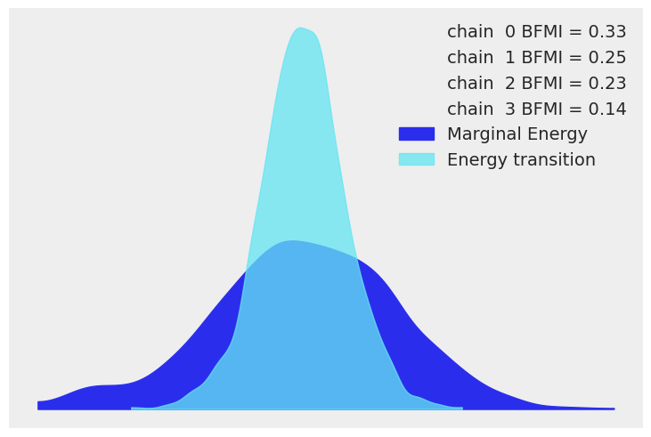

```julia
plot_energy(idata);
gcf()
```

### Additional information in Turing.jl

With a few more steps, we can use Turing to compute additional useful groups to add to the `InferenceData`.

To sample from the prior, one simply calls `sample` but with the `Prior` sampler:

```julia
prior = sample(param_mod, Prior(), nsamples; progress = false)
```

```
Chains MCMC chain (1000×11×1 Array{Float64,3}):

Iterations        = 1:1000
Thinning interval = 1
Chains            = 1
Samples per chain = 1000
parameters        = θ[1], θ[2], θ[3], θ[4], θ[5], θ[6], θ[7], θ[8], μ, τ
internals         = lp

Summary Statistics
  parameters      mean       std   naive_se      mcse         ess      rhat
      Symbol   Float64   Float64    Float64   Float64     Float64   Float64

        θ[1]    0.9437   67.9184     2.1478    3.0807    556.5721    1.0001
        θ[2]   -0.6113   48.9282     1.5472    1.1096   1023.9913    1.0000
        θ[3]   -1.1874   60.8370     1.9238    1.4449    999.5571    0.9991
        θ[4]    0.1588   52.6023     1.6634    2.0985    812.8250    1.0025
        θ[5]    1.7428   71.2371     2.2527    2.2148    918.9025    0.9993
        θ[6]    2.0271   74.2805     2.3490    2.8746   1004.2599    1.0024
        θ[7]    1.1439   53.3499     1.6871    0.9483   1044.3923    0.9991
        θ[8]    0.7388   58.6210     1.8538    1.8743    964.9287    1.0012
           μ    0.0436    4.8547     0.1535    0.1428   1027.7394    1.0001
           τ   18.2513   68.3494     2.1614    3.0856    638.1239    0.9996

Quantiles
  parameters       2.5%     25.0%     50.0%     75.0%      97.5%
      Symbol    Float64   Float64   Float64   Float64    Float64

        θ[1]   -53.1021   -5.5494    0.0134    5.4924    42.0920
        θ[2]   -47.9095   -4.9937    0.2045    6.0771    38.2048
        θ[3]   -48.4412   -5.0144    0.2915    5.8051    39.0567
        θ[4]   -36.2510   -4.9584    0.4698    6.0296    46.7597
        θ[5]   -41.1661   -5.4494   -0.3852    5.0671    53.3500
        θ[6]   -40.9711   -5.4135    0.2146    5.5908    47.2051
        θ[7]   -39.5905   -5.2035    0.3970    6.4169    50.1237
        θ[8]   -49.2875   -4.9863    0.2679    5.8763    55.9611
           μ    -9.7057   -3.3430   -0.0990    3.3103     9.5634
           τ     0.1994    2.0780    4.9683   11.2756   112.9419
```

To draw from the prior and posterior predictive distributions we can instantiate a "predictive model", i.e. a Turing model but with the observations set to `missing`, and then calling `predict` on the predictive model and the previously drawn samples:

```julia
# Instantiate the predictive model
param_mod_predict = turing_model(J, similar(y, Missing), σ)
# and then sample!
prior_predictive = predict(param_mod_predict, prior)
posterior_predictive = predict(param_mod_predict, turing_chns)
```

```
Chains MCMC chain (1000×8×4 Array{Float64,3}):

Iterations        = 1:1000
Thinning interval = 1
Chains            = 1, 2, 3, 4
Samples per chain = 1000
parameters        = y[1], y[2], y[3], y[4], y[5], y[6], y[7], y[8]
internals         =

Summary Statistics
  parameters      mean       std   naive_se      mcse         ess      rhat
      Symbol   Float64   Float64    Float64   Float64     Float64   Float64

        y[1]    4.5082   16.0150     0.2532    0.2930   3268.5480    1.0007
        y[2]    4.6493   11.9315     0.1887    0.3013   2426.6130    1.0007
        y[3]    4.5704   17.2858     0.2733    0.3852   3246.5857    1.0000
        y[4]    4.6143   12.6587     0.2002    0.2960   3443.9512    1.0005
        y[5]    4.4985   10.6522     0.1684    0.2672   1895.2847    1.0018
        y[6]    4.7272   12.4434     0.1967    0.2517   3152.6502    1.0012
        y[7]    4.3443   11.7323     0.1855    0.2427   3064.7075    1.0001
        y[8]    4.9657   18.9625     0.2998    0.3368   3958.3019    1.0001

Quantiles
  parameters       2.5%     25.0%     50.0%     75.0%     97.5%
      Symbol    Float64   Float64   Float64   Float64   Float64

        y[1]   -26.7190   -6.0134    4.6518   15.1441   35.9749
        y[2]   -18.8314   -3.2552    4.5512   12.5614   27.9407
        y[3]   -29.6524   -6.9376    4.6521   16.0361   38.4275
        y[4]   -20.5275   -3.5383    4.7111   12.8250   29.4160
        y[5]   -15.8879   -2.7019    4.7310   11.4978   25.5380
        y[6]   -19.2152   -3.5181    4.4492   13.2566   28.6721
        y[7]   -19.1155   -3.2005    4.6943   12.0731   26.8739
        y[8]   -31.5715   -8.0353    4.6702   17.8301   41.3367
```

And to extract the pointwise log-likelihoods, which is useful if you want to compute metrics such as `loo`,

```julia
loglikelihoods = Turing.pointwise_loglikelihoods(param_mod, turing_chns)
```

```
Dict{String,Array{Float64,2}} with 8 entries:
  "y[6]" => [-3.36285 -4.08918 -3.39046 -3.32844; -3.81335 -3.62125 -3.38203 -3…
  "y[2]" => [-3.23247 -3.22337 -3.23758 -3.65949; -3.28484 -3.26335 -3.23609 -3…
  "y[1]" => [-4.87426 -4.878 -4.71977 -5.22698; -4.08751 -4.70315 -4.60937 -4.7…
  "y[5]" => [-3.2681 -4.81419 -3.37238 -3.16239; -3.43789 -3.95455 -3.39972 -3.…
  "y[8]" => [-4.03523 -3.81134 -3.86919 -3.86369; -3.81057 -3.82789 -3.86432 -3…
  "y[7]" => [-3.72935 -4.31431 -3.92227 -4.56106; -3.4916 -3.48724 -3.94398 -4.…
  "y[3]" => [-4.06155 -3.84478 -3.85029 -3.69183; -3.73377 -3.69364 -3.85202 -3…
  "y[4]" => [-4.04857 -3.33035 -3.31907 -3.32388; -3.75523 -3.33412 -3.31756 -3…
```

This can then be included in the `from_mcmcchains` call from above:

```julia
using LinearAlgebra
# Ensure the ordering of the loglikelihoods matches the ordering of `posterior_predictive`
ynames = string.(keys(posterior_predictive))
loglikelihoods_vals = getindex.(Ref(loglikelihoods), ynames)
# Reshape into `(nchains, nsamples, size(y)...)`
loglikelihoods_arr = permutedims(cat(loglikelihoods_vals...; dims = 3), (2, 1, 3))

idata = from_mcmcchains(
    turing_chns,
    posterior_predictive = posterior_predictive,
    log_likelihood = Dict("y" => loglikelihoods_arr),
    prior = prior,
    prior_predictive = prior_predictive,
    observed_data = Dict("y" => y),
    coords = Dict("school" => schools),
    dims = Dict(
        "y" => ["school"],
        "σ" => ["school"],
        "θ" => ["school"],
    ),
    library = "Turing"
)
```

InferenceData

- posterior

  ```
  Dataset (xarray.Dataset)
  Dimensions:  (chain: 4, draw: 1000, school: 8)
  Coordinates:
    * chain    (chain) int64 0 1 2 3
    * draw     (draw) int64 0 1 2 3 4 5 6 7 8 ... 992 993 994 995 996 997 998 999
    * school   (school) <U16 'Choate' 'Deerfield' ... "St. Paul's" 'Mt. Hermon'
  Data variables:
      μ        (chain, draw) float64 2.242 7.977 5.731 5.574 ... 4.085 2.973 7.224
      τ        (chain, draw) float64 5.526 6.236 4.726 6.596 ... 2.249 1.253 2.106
      θ        (chain, draw, school) float64 4.309 9.479 10.76 ... 8.703 8.909
  Attributes:
      created_at:         2020-10-21T04:33:10.905364
      arviz_version:      0.10.0
      inference_library:  Turing
  ```

- posterior_predictive

  ```
  Dataset (xarray.Dataset)
  Dimensions:  (chain: 4, draw: 1000, school: 8)
  Coordinates:
    * chain    (chain) int64 0 1 2 3
    * draw     (draw) int64 0 1 2 3 4 5 6 7 8 ... 992 993 994 995 996 997 998 999
    * school   (school) <U16 'Choate' 'Deerfield' ... "St. Paul's" 'Mt. Hermon'
  Data variables:
      y        (chain, draw, school) float64 25.57 11.68 13.62 ... -5.516 40.3
  Attributes:
      created_at:         2020-10-21T04:33:10.409216
      arviz_version:      0.10.0
      inference_library:  Turing
  ```

- log_likelihood

  ```
  Dataset (xarray.Dataset)
  Dimensions:  (chain: 4, draw: 1000, school: 8)
  Coordinates:
    * chain    (chain) int64 0 1 2 3
    * draw     (draw) int64 0 1 2 3 4 5 6 7 8 ... 992 993 994 995 996 997 998 999
    * school   (school) <U16 'Choate' 'Deerfield' ... "St. Paul's" 'Mt. Hermon'
  Data variables:
      y        (chain, draw, school) float64 -4.874 -3.232 ... -3.654 -3.824
  Attributes:
      created_at:         2020-10-21T04:33:10.846388
      arviz_version:      0.10.0
      inference_library:  Turing
  ```

- sample_stats

  ```
  Dataset (xarray.Dataset)
  Dimensions:           (chain: 4, draw: 1000)
  Coordinates:
    * chain             (chain) int64 0 1 2 3
    * draw              (draw) int64 0 1 2 3 4 5 6 ... 993 994 995 996 997 998 999
  Data variables:
      energy            (chain, draw) float64 64.14 65.4 63.17 ... 54.05 54.95
      energy_error      (chain, draw) float64 -0.02879 0.04508 ... -0.05148
      depth             (chain, draw) int64 4 4 4 4 4 4 4 4 4 ... 3 4 4 3 4 4 3 5
      diverging         (chain, draw) bool False False False ... False False False
      log_density       (chain, draw) float64 -59.74 -59.23 ... -48.34 -49.35
      max_energy_error  (chain, draw) float64 -0.03812 0.08593 ... -0.7244 -0.6883
      nom_step_size     (chain, draw) float64 0.2857 0.2857 ... 0.09645 0.09645
      is_accept         (chain, draw) float64 1.0 1.0 1.0 1.0 ... 1.0 1.0 1.0 1.0
      tree_size         (chain, draw) int64 15 15 15 15 15 15 ... 15 15 15 15 47
      lp                (chain, draw) float64 -59.74 -59.23 ... -48.34 -49.35
      step_size         (chain, draw) float64 0.2857 0.2857 ... 0.09645 0.09645
      mean_tree_accept  (chain, draw) float64 0.9954 0.9501 ... 0.959 0.9753
  Attributes:
      created_at:         2020-10-21T04:33:10.909487
      arviz_version:      0.10.0
      inference_library:  Turing
  ```

- prior

  ```
  Dataset (xarray.Dataset)
  Dimensions:  (chain: 1, draw: 1000, school: 8)
  Coordinates:
    * chain    (chain) int64 0
    * draw     (draw) int64 0 1 2 3 4 5 6 7 8 ... 992 993 994 995 996 997 998 999
    * school   (school) <U16 'Choate' 'Deerfield' ... "St. Paul's" 'Mt. Hermon'
  Data variables:
      μ        (chain, draw) float64 -3.59 7.95 2.976 ... -2.541 -5.66 -3.953
      τ        (chain, draw) float64 4.819 0.8977 2.399 ... 9.565 7.004 0.5758
      θ        (chain, draw, school) float64 1.91 -4.607 6.231 ... -4.287 -3.628
  Attributes:
      created_at:         2020-10-21T04:33:11.316786
      arviz_version:      0.10.0
      inference_library:  Turing
  ```

- prior_predictive

  ```
  Dataset (xarray.Dataset)
  Dimensions:  (chain: 1, draw: 1000, school: 8)
  Coordinates:
    * chain    (chain) int64 0
    * draw     (draw) int64 0 1 2 3 4 5 6 7 8 ... 992 993 994 995 996 997 998 999
    * school   (school) <U16 'Choate' 'Deerfield' ... "St. Paul's" 'Mt. Hermon'
  Data variables:
      y        (chain, draw, school) float64 12.63 -22.35 29.94 ... 1.514 -8.327
  Attributes:
      created_at:         2020-10-21T04:33:11.167423
      arviz_version:      0.10.0
      inference_library:  Turing
  ```

- sample_stats_prior

  ```
  Dataset (xarray.Dataset)
  Dimensions:  (chain: 1, draw: 1000)
  Coordinates:
    * chain    (chain) int64 0
    * draw     (draw) int64 0 1 2 3 4 5 6 7 8 ... 992 993 994 995 996 997 998 999
  Data variables:
      lp       (chain, draw) float64 -65.73 -43.9 -53.15 ... -71.98 -66.78 -45.63
  Attributes:
      created_at:         2020-10-21T04:33:11.371617
      arviz_version:      0.10.0
      inference_library:  Turing
  ```

- observed_data

  ```
  Dataset (xarray.Dataset)
  Dimensions:  (school: 8)
  Coordinates:
    * school   (school) <U16 'Choate' 'Deerfield' ... "St. Paul's" 'Mt. Hermon'
  Data variables:
      y        (school) float64 28.0 8.0 -3.0 7.0 -1.0 1.0 18.0 12.0
  Attributes:
      created_at:         2020-10-21T04:33:12.072733
      arviz_version:      0.10.0
      inference_library:  Turing
  ```

Then we can for example compute the expected *leave-one-out (LOO)* predictive density, which is an estimate of the out-of-distribution predictive fit of the model:

```julia
loo(idata) # higher is better
```

|  | loo Float64 | loo_se Float64 | p_loo Float64 | n_samples Int64 | n_data_points Int64 | warning Bool | loo_scale String |
| --- | --- | --- | --- | --- | --- | --- | --- |
| 1 | -30.7109 | 1.34611 | 0.881344 | 4000 | 8 | 0 | log |

If the model is well-calibrated, i.e. it replicates the true generative process well, the CDF of the pointwise LOO values should be similarly distributed to a uniform distribution. This can be inspected visually:

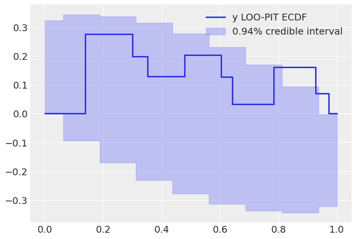

```julia
plot_loo_pit(idata; y = "y", ecdf = true);
gcf()
```

## Plotting with CmdStan.jl outputs

CmdStan.jl and StanSample.jl also default to producing `Chains` outputs, and we can easily plot these chains.

Here is the same centered eight schools model:

```julia
using CmdStan, MCMCChains

schools_code = """
data {
  int<lower=0> J;
  real y[J];
  real<lower=0> sigma[J];
}

parameters {
  real mu;
  real<lower=0> tau;
  real theta[J];
}

model {
  mu ~ normal(0, 5);
  tau ~ cauchy(0, 5);
  theta ~ normal(mu, tau);
  y ~ normal(theta, sigma);
}

generated quantities {
    vector[J] log_lik;
    vector[J] y_hat;
    for (j in 1:J) {
        log_lik[j] = normal_lpdf(y[j] | theta[j], sigma[j]);
        y_hat[j] = normal_rng(theta[j], sigma[j]);
    }
}
"""

schools_dat = Dict("J" => J, "y" => y, "sigma" => σ)
stan_model = Stanmodel(
    model = schools_code,
    name = "schools",
    nchains = nchains,
    num_warmup = nwarmup,
    num_samples = nsamples,
    output_format = :mcmcchains,
    random = CmdStan.Random(28983),
)
_, stan_chns, _ = stan(stan_model, schools_dat, summary = false);
```

```
File /home/runner/work/ArviZ.jl/ArviZ.jl/docs/build/tmp/schools.stan will be updated.
```

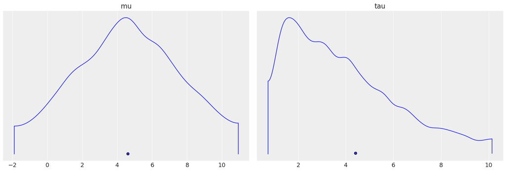

```julia
plot_density(stan_chns; var_names=["mu", "tau"]);
gcf()
```

Again, converting to `InferenceData`, we can get much richer labelling and mixing of data. Note that we're using the same `from_cmdstan` function used by ArviZ to process cmdstan output files, but through the power of dispatch in Julia, if we pass a `Chains` object, it instead uses ArviZ.jl's overloads, which forward to `from_mcmcchains`.

```julia
idata = from_cmdstan(
    stan_chns;
    posterior_predictive = "y_hat",
    observed_data = Dict("y" => schools_dat["y"]),
    log_likelihood = "log_lik",
    coords = Dict("school" => schools),
    dims = Dict(
        "y" => ["school"],
        "sigma" => ["school"],
        "theta" => ["school"],
        "log_lik" => ["school"],
        "y_hat" => ["school"],
    ),
)
```

InferenceData

- posterior

  ```
  Dataset (xarray.Dataset)
  Dimensions:  (chain: 4, draw: 1000, school: 8)
  Coordinates:
    * chain    (chain) int64 0 1 2 3
    * draw     (draw) int64 0 1 2 3 4 5 6 7 8 ... 992 993 994 995 996 997 998 999
    * school   (school) <U16 'Choate' 'Deerfield' ... "St. Paul's" 'Mt. Hermon'
  Data variables:
      theta    (chain, draw, school) float64 -0.165 0.7155 -9.24 ... 6.625 6.425
      tau      (chain, draw) float64 7.914 3.891 4.143 2.586 ... 1.266 1.731 1.655
      mu       (chain, draw) float64 0.2775 6.939 6.782 ... 5.958 5.052 5.926
  Attributes:
      created_at:         2020-10-21T04:34:07.854704
      arviz_version:      0.10.0
      inference_library:  CmdStan
  ```

- posterior_predictive

  ```
  Dataset (xarray.Dataset)
  Dimensions:  (chain: 4, draw: 1000, school: 8)
  Coordinates:
    * chain    (chain) int64 0 1 2 3
    * draw     (draw) int64 0 1 2 3 4 5 6 7 8 ... 992 993 994 995 996 997 998 999
    * school   (school) <U16 'Choate' 'Deerfield' ... "St. Paul's" 'Mt. Hermon'
  Data variables:
      y_hat    (chain, draw, school) float64 -18.59 -8.772 -9.08 ... 19.1 -13.76
  Attributes:
      created_at:         2020-10-21T04:34:07.814971
      arviz_version:      0.10.0
      inference_library:  CmdStan
  ```

- log_likelihood

  ```
  Dataset (xarray.Dataset)
  Dimensions:  (chain: 4, draw: 1000, school: 8)
  Coordinates:
    * chain    (chain) int64 0 1 2 3
    * draw     (draw) int64 0 1 2 3 4 5 6 7 8 ... 992 993 994 995 996 997 998 999
    * school   (school) <U16 'Choate' 'Deerfield' ... "St. Paul's" 'Mt. Hermon'
  Data variables:
      log_lik  (chain, draw, school) float64 -5.39 -3.487 -3.768 ... -3.869 -3.857
  Attributes:
      created_at:         2020-10-21T04:34:07.828989
      arviz_version:      0.10.0
      inference_library:  CmdStan
  ```

- sample_stats

  ```
  Dataset (xarray.Dataset)
  Dimensions:      (chain: 4, draw: 1000)
  Coordinates:
    * chain        (chain) int64 0 1 2 3
    * draw         (draw) int64 0 1 2 3 4 5 6 7 ... 993 994 995 996 997 998 999
  Data variables:
      stepsize     (chain, draw) float64 0.2197 0.2197 0.2197 ... 0.1829 0.1829
      treedepth    (chain, draw) float64 4.0 4.0 4.0 4.0 4.0 ... 4.0 3.0 3.0 3.0
      n_leapfrog   (chain, draw) float64 15.0 31.0 15.0 15.0 ... 15.0 13.0 7.0
      accept_stat  (chain, draw) float64 0.9642 0.9569 0.9648 ... 0.7453 0.9197
      diverging    (chain, draw) bool False False False ... False False False
      energy       (chain, draw) float64 27.49 25.64 21.91 ... 13.36 10.67 12.01
      lp           (chain, draw) float64 -23.04 -16.01 -15.29 ... -8.88 -9.041
  Attributes:
      created_at:         2020-10-21T04:34:07.869097
      arviz_version:      0.10.0
      inference_library:  CmdStan
  ```

- observed_data

  ```
  Dataset (xarray.Dataset)
  Dimensions:  (school: 8)
  Coordinates:
    * school   (school) <U16 'Choate' 'Deerfield' ... "St. Paul's" 'Mt. Hermon'
  Data variables:
      y        (school) float64 28.0 8.0 -3.0 7.0 -1.0 1.0 18.0 12.0
  Attributes:
      created_at:         2020-10-21T04:34:07.909052
      arviz_version:      0.10.0
      inference_library:  CmdStan
  ```

Here is a plot showing where the Hamiltonian sampler had divergences:

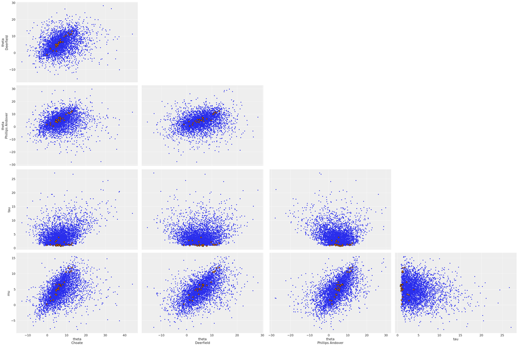

```julia
plot_pair(
    idata;
    coords = Dict("school" => ["Choate", "Deerfield", "Phillips Andover"]),
    divergences = true,
);
gcf()
```

## Plotting with Soss.jl outputs

With Soss, we can define our model for the posterior and easily use it to draw samples from the prior, prior predictive, posterior, and posterior predictive distributions.

First we define our model:

```julia
using Soss, NamedTupleTools

mod = Soss.@model (J, σ) begin
    μ ~ Normal(0, 5)
    τ ~ HalfCauchy(5)
    θ ~ Normal(μ, τ) |> iid(J)
    y ~ For(1:J) do j
        Normal(θ[j], σ[j])
    end
end

constant_data = (J = J, σ = σ)
param_mod = mod(; constant_data...)
```

```
Joint Distribution
    Bound arguments: [J, σ]
    Variables: [τ, μ, θ, y]

@model (J, σ) begin
        τ ~ HalfCauchy(5)
        μ ~ Normal(0, 5)
        θ ~ Normal(μ, τ) |> iid(J)
        y ~ For(1:J) do j
                Normal(θ[j], σ[j])
            end
    end
```

Then we draw from the prior and prior predictive distributions.

```julia
Random.seed!(5298)
prior_priorpred = [
    map(1:nchains*nsamples) do _
        draw = rand(param_mod)
        return delete(draw, keys(constant_data))
    end
];
```

Next, we draw from the posterior using DynamicHMC.jl.

```julia
post = map(1:nchains) do _
    dynamicHMC(param_mod, (y = y,), nsamples)
end;
```

Finally, we update the posterior samples with draws from the posterior predictive distribution.

```julia
pred = predictive(mod, :μ, :τ, :θ)
post_postpred = map(post) do post_draws
    map(post_draws) do post_draw
        pred_draw = rand(pred(post_draw))
        pred_draw = delete(pred_draw, keys(constant_data))
        return merge(pred_draw, post_draw)
    end
end;
```

Each Soss draw is a `NamedTuple`. We can plot the rank order statistics of the posterior to identify poor convergence:

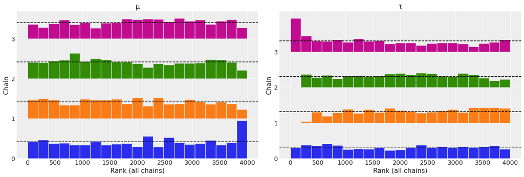

```julia
plot_rank(post; var_names = ["μ", "τ"]);
gcf()
```

Now we combine all of the samples to an `InferenceData`:

```julia
idata = from_namedtuple(
    post_postpred;
    posterior_predictive = [:y],
    prior = prior_priorpred,
    prior_predictive = [:y],
    observed_data = (y = y,),
    constant_data = constant_data,
    coords = Dict("school" => schools),
    dims = Dict(
        "y" => ["school"],
        "σ" => ["school"],
        "θ" => ["school"],
    ),
    library = Soss,
)
```

InferenceData

- posterior

  ```
  Dataset (xarray.Dataset)
  Dimensions:  (chain: 4, draw: 1000, school: 8)
  Coordinates:
    * chain    (chain) int64 0 1 2 3
    * draw     (draw) int64 0 1 2 3 4 5 6 7 8 ... 992 993 994 995 996 997 998 999
    * school   (school) <U16 'Choate' 'Deerfield' ... "St. Paul's" 'Mt. Hermon'
  Data variables:
      μ        (chain, draw) float64 -0.2821 -2.515 3.409 ... 11.26 8.506 8.948
      τ        (chain, draw) float64 6.09 10.71 3.243 3.181 ... 2.033 2.397 2.114
      θ        (chain, draw, school) float64 6.039 -2.826 0.1498 ... 12.7 6.617
  Attributes:
      created_at:         2020-10-21T04:38:16.277792
      arviz_version:      0.10.0
      inference_library:  Soss
  ```

- posterior_predictive

  ```
  Dataset (xarray.Dataset)
  Dimensions:  (chain: 4, draw: 1000, school: 8)
  Coordinates:
    * chain    (chain) int64 0 1 2 3
    * draw     (draw) int64 0 1 2 3 4 5 6 7 8 ... 992 993 994 995 996 997 998 999
    * school   (school) <U16 'Choate' 'Deerfield' ... "St. Paul's" 'Mt. Hermon'
  Data variables:
      y        (chain, draw, school) float64 0.9461 7.547 ... -1.261 -0.9876
  Attributes:
      created_at:         2020-10-21T04:38:16.242570
      arviz_version:      0.10.0
      inference_library:  Soss
  ```

- prior

  ```
  Dataset (xarray.Dataset)
  Dimensions:  (chain: 1, draw: 4000, school: 8)
  Coordinates:
    * chain    (chain) int64 0
    * draw     (draw) int64 0 1 2 3 4 5 6 7 ... 3993 3994 3995 3996 3997 3998 3999
    * school   (school) <U16 'Choate' 'Deerfield' ... "St. Paul's" 'Mt. Hermon'
  Data variables:
      μ        (chain, draw) float64 -1.058 6.136 -0.3852 ... 1.484 -10.82 -0.7505
      τ        (chain, draw) float64 149.7 0.02342 3.398 ... 4.347 84.28 4.543
      θ        (chain, draw, school) float64 -8.511 154.9 44.86 ... -2.911 -6.732
  Attributes:
      created_at:         2020-10-21T04:38:17.350708
      arviz_version:      0.10.0
      inference_library:  Soss
  ```

- prior_predictive

  ```
  Dataset (xarray.Dataset)
  Dimensions:  (chain: 1, draw: 4000, school: 8)
  Coordinates:
    * chain    (chain) int64 0
    * draw     (draw) int64 0 1 2 3 4 5 6 7 ... 3993 3994 3995 3996 3997 3998 3999
    * school   (school) <U16 'Choate' 'Deerfield' ... "St. Paul's" 'Mt. Hermon'
  Data variables:
      y        (chain, draw, school) float64 -19.44 137.9 18.57 ... 5.947 13.3
  Attributes:
      created_at:         2020-10-21T04:38:17.348517
      arviz_version:      0.10.0
      inference_library:  Soss
  ```

- observed_data

  ```
  Dataset (xarray.Dataset)
  Dimensions:  (school: 8, y_dim_0: 8)
  Coordinates:
    * y_dim_0  (y_dim_0) int64 0 1 2 3 4 5 6 7
    * school   (school) <U16 'Choate' 'Deerfield' ... "St. Paul's" 'Mt. Hermon'
  Data variables:
      y        (y_dim_0) float64 28.0 8.0 -3.0 7.0 -1.0 1.0 18.0 12.0
  Attributes:
      created_at:         2020-10-21T04:38:18.184360
      arviz_version:      0.10.0
      inference_library:  Soss
  ```

- constant_data

  ```
  Dataset (xarray.Dataset)
  Dimensions:  (J_dim_0: 1, school: 8, σ_dim_0: 8)
  Coordinates:
    * J_dim_0  (J_dim_0) int64 0
    * σ_dim_0  (σ_dim_0) int64 0 1 2 3 4 5 6 7
    * school   (school) <U16 'Choate' 'Deerfield' ... "St. Paul's" 'Mt. Hermon'
  Data variables:
      J        (J_dim_0) int64 8
      σ        (σ_dim_0) float64 15.0 10.0 16.0 11.0 9.0 11.0 10.0 18.0
  Attributes:
      created_at:         2020-10-21T04:38:18.793154
      arviz_version:      0.10.0
      inference_library:  Soss
  ```

We can compare the prior and posterior predictive distributions:

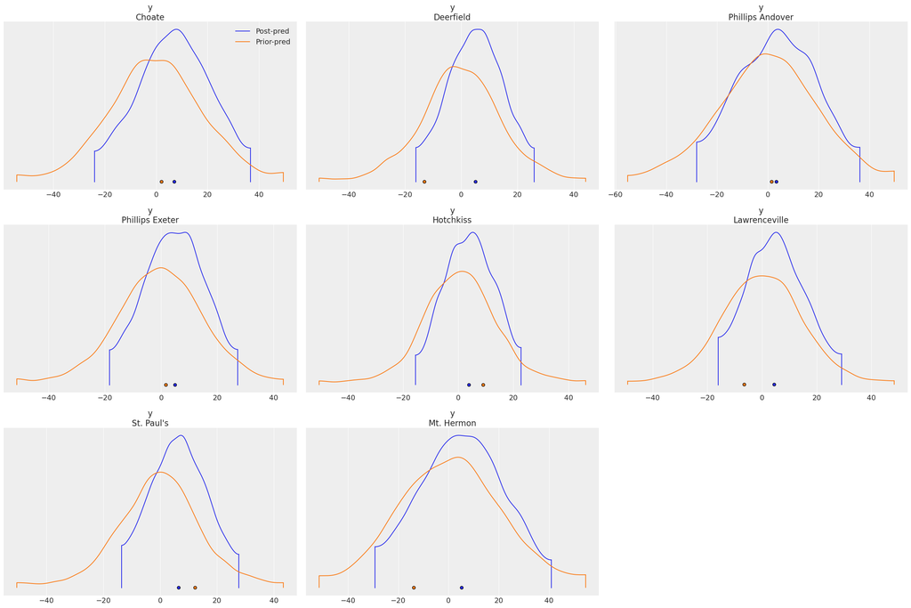

```julia
plot_density(
    [idata.posterior_predictive, idata.prior_predictive];
    data_labels = ["Post-pred", "Prior-pred"],
    var_names = ["y"],
)
gcf()
```

## Environment

```julia
using Pkg
Pkg.status()
```

```
Status `~/work/ArviZ.jl/ArviZ.jl/docs/Project.toml`
  [131c737c] ArviZ v0.4.6 `~/work/ArviZ.jl/ArviZ.jl`
  [593b3428] CmdStan v6.0.9
  [31c24e10] Distributions v0.23.8
  [e30172f5] Documenter v0.25.2
  [c7f686f2] MCMCChains v4.2.4
  [d9ec5142] NamedTupleTools v0.13.6
  [438e738f] PyCall v1.92.1
  [d330b81b] PyPlot v2.9.0
  [8ce77f84] Soss v0.14.4
  [fce5fe82] Turing v0.14.10
  [37e2e46d] LinearAlgebra
```

```julia
using InteractiveUtils
versioninfo()
```

```
Julia Version 1.5.2
Commit 539f3ce943 (2020-09-23 23:17 UTC)
Platform Info:
  OS: Linux (x86_64-pc-linux-gnu)
  CPU: Intel(R) Xeon(R) Platinum 8171M CPU @ 2.60GHz
  WORD_SIZE: 64
  LIBM: libopenlibm
  LLVM: libLLVM-9.0.1 (ORCJIT, skylake-avx512)
Environment:
  JULIA_CMDSTAN_HOME = /home/runner/work/ArviZ.jl/ArviZ.jl/.cmdstan//cmdstan-2.23.0/
  JULIA_NUM_THREADS = 2
```